# Guided Project: Answering Business Questions using SQL

Install packages for working with SQLite

```r
library(RSQLite)
library(DBI)
```

Create a function to take in a query and return the result in a dataframe

```r
run_query <- function(query) {
  conn <- dbConnect(SQLite(), 'chinook.db')
  result <- dbGetQuery(conn, query)
  dbDisconnect(conn)
  return(result)
}
```

Create a function to call run_query() function and return list of all tables and views in DB

```r
show_tables <- function() {
  query = "SELECT name, type FROM sqlite_master WHERE type IN ('table', 'view');"
  return(run_query(query))
}
```

```r
show_tables()
```

| name | type |
| --- | --- |
| album | table |
| artist | table |
| customer | table |
| employee | table |
| genre | table |
| invoice | table |
| invoice_line | table |
| media_type | table |
| playlist | table |
| playlist_track | table |

[output cut: 1 more lines]

```r
q1 = '
WITH usa_tracks_sold AS
(
  SELECT
    il.*
  FROM invoice_line il
  INNER JOIN invoice i ON il.invoice_id = i.invoice_id
  INNER JOIN customer c ON i.customer_id = c.customer_id
  WHERE c.country = "USA"
)

SELECT
  g.name genre,
  count(uts.invoice_line_id) tracks_sold,
  cast(count(uts.invoice_line_id) AS FLOAT) / (SELECT COUNT(*) FROM usa_tracks_sold) percentage_sold
FROM genre g
INNER JOIN track t ON g.genre_id = t.genre_id
INNER JOIN usa_tracks_sold uts ON t.track_id = uts.track_id
GROUP BY 1
ORDER BY 2 DESC
LIMIT 10;
'

run_query(q1)
```

| genre | tracks_sold | percentage_sold |
| --- | --- | --- |
| Rock | 561 | 0.53377735 |
| Alternative & Punk | 130 | 0.12369172 |
| Metal | 124 | 0.11798287 |
| R&B/Soul | 53 | 0.05042816 |
| Blues | 36 | 0.03425309 |
| Alternative | 35 | 0.03330162 |
| Pop | 22 | 0.02093245 |
| Latin | 22 | 0.02093245 |
| Hip Hop/Rap | 20 | 0.01902950 |
| Jazz | 14 | 0.01332065 |

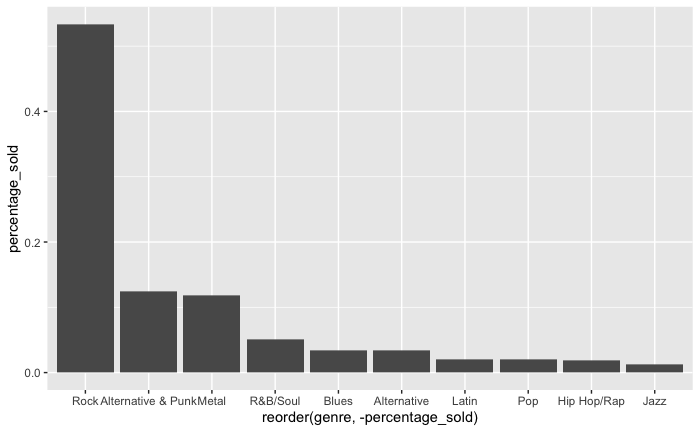

```r
library(ggplot2)

genre_sales_usa = run_query(q1)
ggplot(data=genre_sales_usa) +
  aes(x = reorder(genre, -percentage_sold), y = percentage_sold) +
  geom_bar(stat = 'identity')
```

1. Red Tone (Punk)
2. Slim Jim Bites(Blues)
3. Meteor and the Girls (Pop)

However, even given these choices, Rock is still the majority of sales. We should really look at alternatives that fall under the Rock genre.

```r
q2 = '
WITH customer_support_rep_sales AS
(
  SELECT
    i.customer_id,
    c.support_rep_id,
    SUM(i.total) total_sales
  FROM customer c
  INNER JOIN invoice i ON c.customer_id = i.customer_id
  GROUP BY 1, 2
)

SELECT
  e.first_name || " " || e.last_name employee_name,
  e.hire_date,
  SUM(csrs.total_sales) total_sales
FROM customer_support_rep_sales csrs
INNER JOIN employee e ON e.employee_id = csrs.support_rep_id
GROUP BY 1;
'

run_query(q2)
```

| employee_name | hire_date | total_sales |
| --- | --- | --- |
| Jane Peacock | 2017-04-01 00:00:00 | 1731.51 |
| Margaret Park | 2017-05-03 00:00:00 | 1584.00 |
| Steve Johnson | 2017-10-17 00:00:00 | 1393.92 |

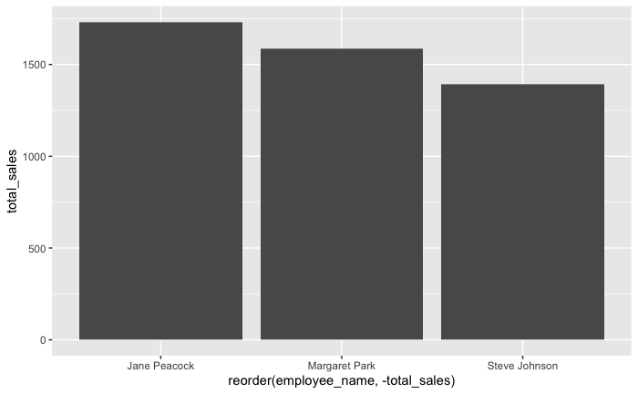

```r
employee_sales = run_query(q2)
ggplot(data = employee_sales, aes(x = reorder(employee_name, -total_sales), y = total_sales)) +
  geom_bar(stat = 'identity')
```

Looking at the raw results, Jane Peacock had the most sales. However, considering that total sales were higher as length of time of employment increased, it is a little harder to see who is performing best. We would probably have better insight if we were to normalize the sales based on lenght of employment.

```r
q3 = '
WITH country_or_other AS
(
  SELECT
    CASE
      WHEN (
            SELECT COUNT(*)
            FROM customer
            WHERE country = c.country
            ) = 1 THEN "Other"
      ELSE c.country
    END country,
    c.customer_id,
    il.*
  FROM customer c
  INNER JOIN invoice i ON i.customer_id = c.customer_id
  INNER JOIN invoice_line il ON i.invoice_id = il.invoice_id
)

SELECT
  country,
  num_customers,
  total_sales,
  customer_lifetime_value,
  average_order_value
FROM (
      SELECT
        country,
        count(distinct customer_id) num_customers,
        SUM(unit_price) total_sales,
        SUM(unit_price) / count(distinct customer_id) customer_lifetime_value,
        SUM(unit_price) / count(distinct invoice_id) average_order_value,
        CASE
          WHEN country = "Other" THEN 1
          ELSE 0
        END sort
      FROM country_or_other
      GROUP BY country
      ORDER BY 6, 3 DESC
      );
'
run_query(q3)
```

| country | num_customers | total_sales | customer_lifetime_value | average_order_value |
| --- | --- | --- | --- | --- |
| USA | 13 | 1040.49 | 80.03769 | 7.942672 |
| Canada | 8 | 535.59 | 66.94875 | 7.047237 |
| Brazil | 5 | 427.68 | 85.53600 | 7.011148 |
| France | 5 | 389.07 | 77.81400 | 7.781400 |
| Germany | 4 | 334.62 | 83.65500 | 8.161463 |
| Czech Republic | 2 | 273.24 | 136.62000 | 9.108000 |
| United Kingdom | 3 | 245.52 | 81.84000 | 8.768571 |
| Portugal | 2 | 185.13 | 92.56500 | 6.383793 |
| India | 2 | 183.15 | 91.57500 | 8.721429 |
| Other | 15 | 1094.94 | 72.99600 | 7.448571 |

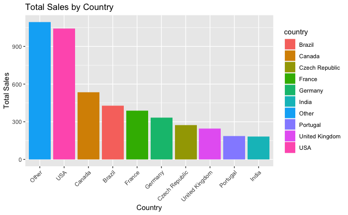

```r
country_details = run_query(q3)

ggplot(data = country_details, aes(x = reorder(country, -total_sales), y = total_sales, fill = country)) +
  geom_bar(stat = 'identity') +
  labs(title = 'Total Sales by Country',
       x = 'Country',
       y = 'Total Sales') +
  theme(axis.text.x = element_text(angle = 45, hjust = 1))
```

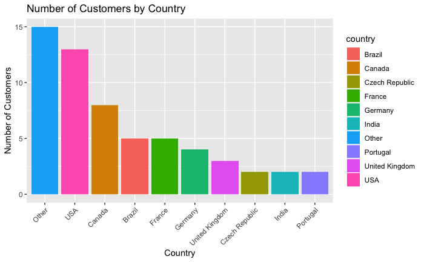

```r
ggplot(data = country_details, aes(x = reorder(country, -num_customers), y = num_customers, fill = country)) +
  geom_bar(stat = 'identity') +
  labs(title = 'Number of Customers by Country',
       x = 'Country',
       y = 'Number of Customers') +
  theme(axis.text.x = element_text(angle = 45, hjust = 1))
```

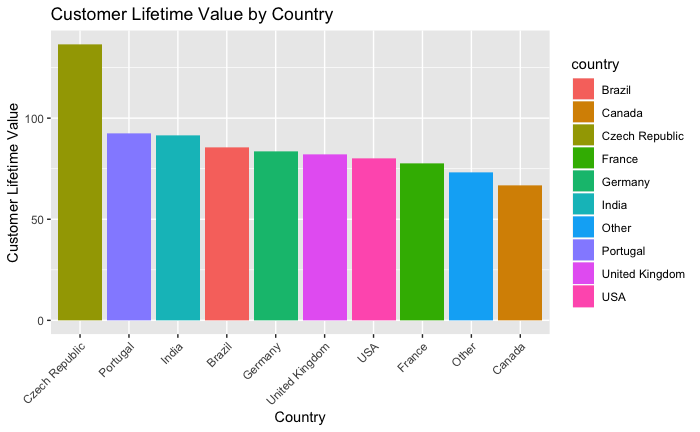

```r
ggplot(data = country_details, aes(x = reorder(country, -customer_lifetime_value), y = customer_lifetime_value, fill = country)) +
  geom_bar(stat = 'identity') +
  labs(title = 'Customer Lifetime Value by Country',
       x = 'Country',
       y = 'Customer Lifetime Value') +
  theme(axis.text.x = element_text(angle = 45, hjust = 1))
```

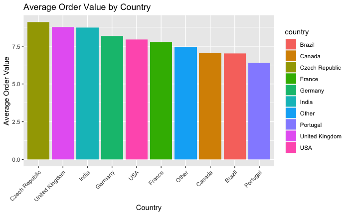

```r
ggplot(data = country_details, aes(x = reorder(country, -average_order_value), y = average_order_value, fill = country)) +
  geom_bar(stat = 'identity') +
  labs(title = 'Average Order Value by Country',
       x = 'Country',
       y = 'Average Order Value') +
  theme(axis.text.x = element_text(angle = 45, hjust = 1))
```

USA definitely has the most customers, but the value per customer seems to be lower than some others. Some interesting countries to pursue might be the Czech Republic, India, Portugal and United Kingdom. All of these have a lower number of customers, however, the customers all seem to spend more on average. This may indicate that these markets would be more lucrative if they were built up further.

```r
q4 = '
WITH invoice_first_track AS
(
  SELECT
    il.invoice_id,
    MIN(il.track_id) first_track_id
  FROM invoice_line il
  GROUP BY 1
)

SELECT
  album_purchase,
  COUNT(invoice_id) num_invoices,
  CAST(COUNT(invoice_id) AS FLOAT) / (
                                      SELECT COUNT(*) FROM invoice
                                      ) percent_of_invoices
FROM (
        SELECT
          ifs.*,
          CASE
            WHEN
              (SELECT
                  t.track_id
                FROM track t
                WHERE t.album_id = (
                                    SELECT t2.album_id FROM track t2
                                    WHERE t2.track_id = ifs.first_track_id
                                    )

                EXCEPT

                SELECT il2.track_id FROM invoice_line il2
                WHERE il2.invoice_id = ifs.invoice_id
              ) IS NULL
            AND
              (
              SELECT il2.track_id FROM invoice_line il2
              WHERE il2.invoice_id = ifs.invoice_id

              EXCEPT

              SELECT t.track_id FROM track t
              WHERE t.album_id = (
                                  SELECT t2.album_id FROM track t2
                                  WHERE t2.track_id = ifs.first_track_id
                                  )
              ) IS NULL
            THEN "yes"
            ELSE "no"
          END album_purchase
        FROM invoice_first_track ifs
      )
GROUP BY album_purchase;
'

run_query(q4)
```

| album_purchase | num_invoices | percent_of_invoices |
| --- | --- | --- |
| no | 500 | 0.8143322 |
| yes | 114 | 0.1856678 |

Based on findings, album purchases are about 18% of all purchases. While this is by far, lower than the non-album purchases, we would be losing out on a significant amount of sales if we went to only track purchases. I would still recommend that albums be bought to keep more of the market.